# ch8-lecture

S Zimine

7/10/2018

# Decision Trees

We look at the `Carseats` data using `tree` package. We shall create a binary response variable `High` (for high sales ) and include it in the same dataframe.

```r
require(ISLR)
require(tree)
```

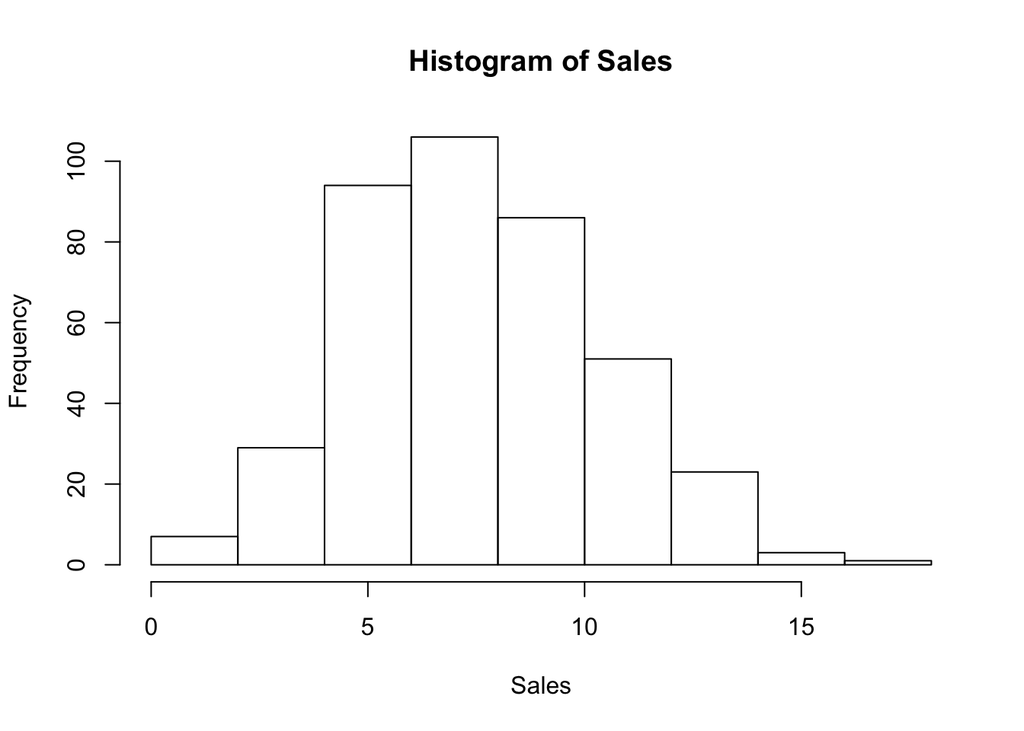

```r
attach(Carseats) #in ISLR
hist(Sales)
```

```r
High<- ifelse(Sales<=8, "No", "Yes")
Carseats <- data.frame(Carseats,High)
```

Now we fit a tree to this data and plot it. Note the exclusion of Sales as the response `High` is derived from it

```r
tree.carseats <- tree(High~.-Sales, data=Carseats)
summary(tree.carseats)
```

```
##
## Classification tree:
## tree(formula = High ~ . - Sales, data = Carseats)
## Variables actually used in tree construction:
## [1] "ShelveLoc"   "Price"       "Income"      "CompPrice"   "Population"
## [6] "Advertising" "Age"         "US"
## Number of terminal nodes:  27
## Residual mean deviance:  0.4575 = 170.7 / 373
## Misclassification error rate: 0.09 = 36 / 400
```

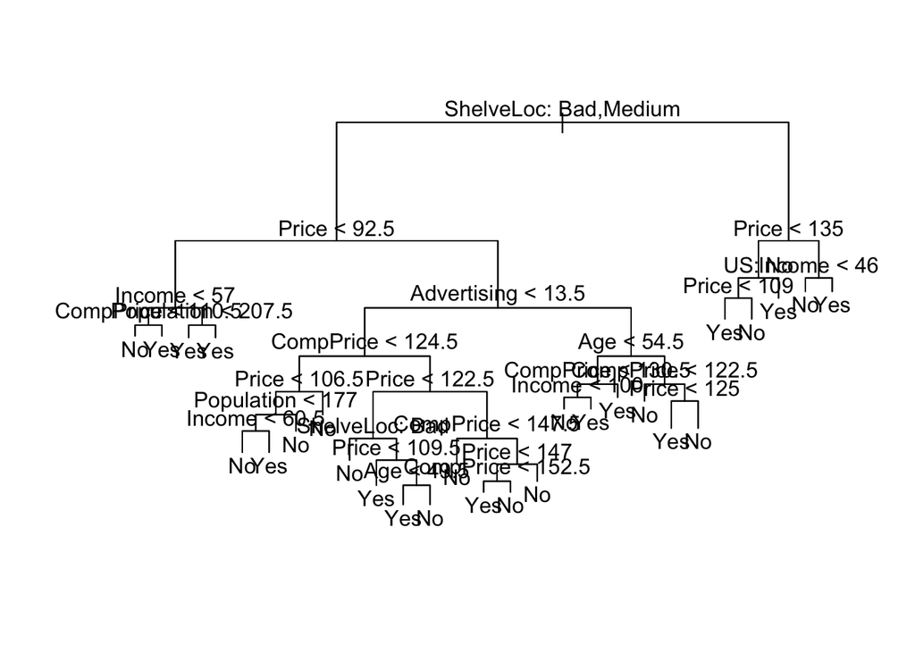

```r
plot(tree.carseats)
text(tree.carseats, pretty=0)
```

You can also print a tree (you see all leafs). Each lines ends up with proporties of `Yes` and `No`

```r
#print(tree.carseats)
```

lets create a training and a test set (250,150) split of 400 observations

```r
set.seed(1011)
nspl <- nrow(Carseats)
train <- sample(1:nspl, 250  )
test <- (1:nspl)[-train]
tree.carseats <- tree(High~.-Sales, data=Carseats, subset=train)
tree.pred <- predict( tree.carseats, Carseats[test,], type="class") #classification
ctbl <- table(tree.pred, Carseats[test,]$High  )
print(ctbl)
```

```
##
## tree.pred No Yes
##       No  72  27
##       Yes 18  33
```

```r
accuracy <- sum(diag(ctbl)) / sum(ctbl)
print(accuracy)
```

```
## [1] 0.7
```

This was a full tree. Lets prune this tree through CV

```r
cv.carseats <- cv.tree(tree.carseats, FUN=prune.misclass)
print(cv.carseats)
```

```
## $size
##  [1] 20 14 13 10  9  7  6  5  2  1
##
## $dev
##  [1]  65  65  57  57  59  64  64  59  78 104
##
## $k
##  [1]      -Inf  0.000000  1.000000  1.333333  2.000000  2.500000  4.000000
##  [8]  5.000000  9.000000 31.000000
##
## $method
## [1] "misclass"
##
## attr(,"class")
## [1] "prune"         "tree.sequence"
```

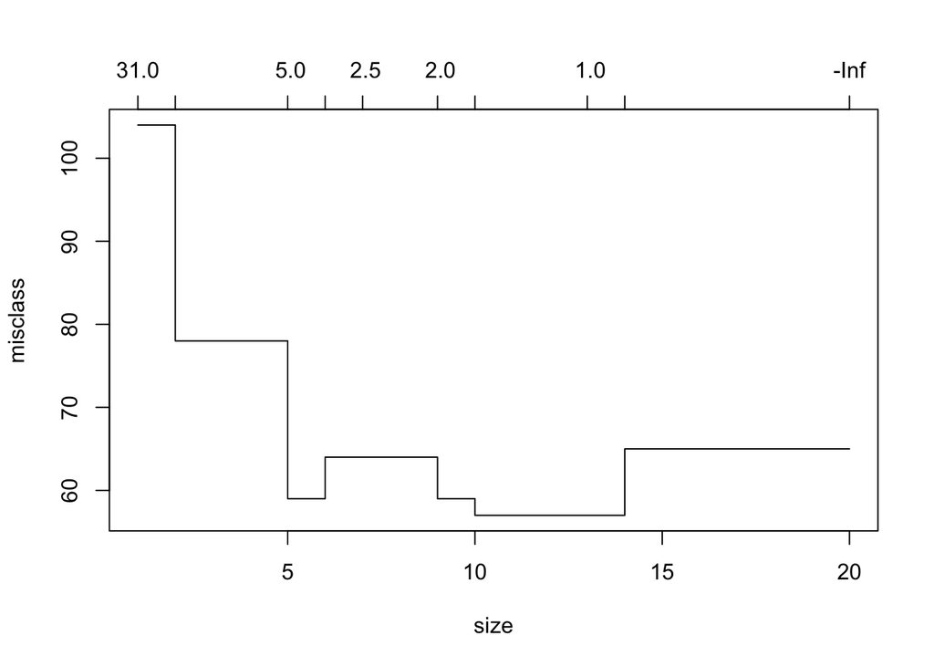

```r
plot(cv.carseats)
```

We prune the tree by taking a size at a minimum of cv curve ie. picking 13

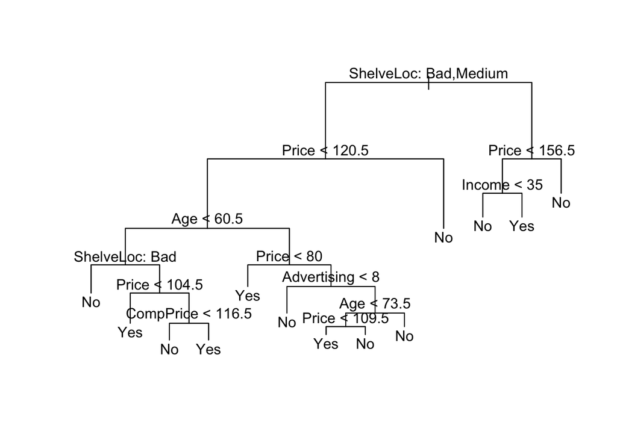

```r
prune.carseats <- prune.misclass(tree.carseats, best=13)
plot(prune.carseats)
text(prune.carseats,pretty=0)
```

no lets evaluate the pruned tree on a test dataset

```r
tree.pred <- predict( prune.carseats, Carseats[test,], type="class") #classification
ctbl <- table(tree.pred, Carseats[test,]$High  )
print(ctbl)
```

```
##
## tree.pred No Yes
##       No  72  28
##       Yes 18  32
```

```r
accuracy <- sum(diag(ctbl)) / sum(ctbl)
print(accuracy)
```

```
## [1] 0.6933333
```

We observe that accuracy of the pruned tree is the same, but pruned tree is easier to interpret

# Random Forests and boosting

This moethods use trees as building blocks to build more complex models. Here we will use the Boston housing data to explore random forests and boosting from the MASS package

Random forests build lots of bushy trees, and then average them to reduce the variance.

```r
require(randomForest)
require(MASS)
set.seed(101)
print(dim(Boston))
```

```
## [1] 506  14
```

```r
nsamb <- nrow(Boston)
tsize <- 300
train <- sample(1:nsamb, tsize)
test <- (1:nsamb)[-train]
```

Fitting a random forest. WE will use the response `medv` (median house value)

```r
rf.boston <- randomForest(medv~.,data=Boston, subset=train)
print(rf.boston)
```

```
##
## Call:
##  randomForest(formula = medv ~ ., data = Boston, subset = train)
##                Type of random forest: regression
##                      Number of trees: 500
## No. of variables tried at each split: 4
##
##           Mean of squared residuals: 12.34243
##                     % Var explained: 85.09
```

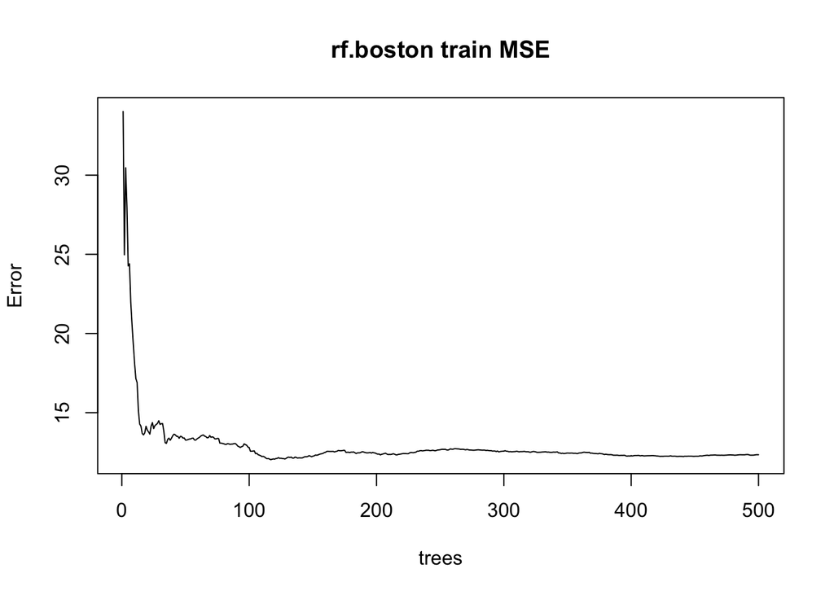

```r
plot(rf.boston, main="rf.boston train MSE")
```

The MSR (mean of squared residuals) and variance explained are based on OOB (out of bag) estimates, a clever trick to get honets error estimates

the mtry reported param has a value 4 . As we have 13 predictor we can vary thiss param between 1 and 13 to check the test MSE

```r
nfeats <- dim(Boston)[2] - 1
oob.err <- rep(NA,nfeats)
test.err <- rep(NA,nfeats)
for( m in 1:nfeats){
    fit <- randomForest(medv~.,data=Boston, subset=train, mtry=m, tree=400)
    oob.err[m] <-fit$mse[400]
    pred <- predict(fit, Boston[test,])
    test.err[m] <- mean( (pred - Boston[test,]$medv)^2  )
    cat(m, " ")
}
```

```
## 1  2  3  4  5  6  7  8  9  10  11  12  13
```

[figure not shown]

```r
#now plotting MSE (takes some time)
data_mat <- cbind(test.err, oob.err)
matplot(1:m, data_mat, pch=19, col=c("red", "blue"), type="b", ylab="test MSE", xlab="mtry" )
legend("topright", legend=c("OOB", "Test"), pch=19, col=c("red","blue"))
```

Not too difficulat. `mtry=13` correspoind to bagging

## Boosting

Boosting builds lots of smaller trees. Unlike random forests, each new tee in boosting tries to patch up the deficiencies of the current ensemble.

```r
require(gbm)
```

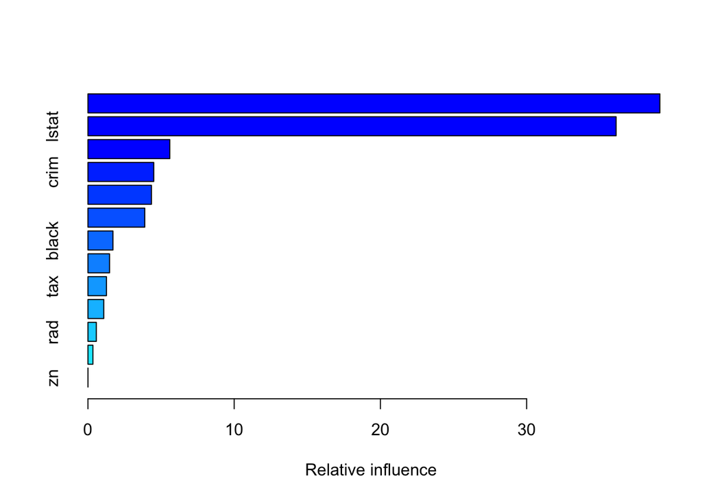

```
##             var      rel.inf
## rm           rm 39.109860136
## lstat     lstat 36.116982558
## dis         dis  5.597609521
## crim       crim  4.500714798
## nox         nox  4.340592056
## ptratio ptratio  3.885905836
## black     black  1.710869608
## age         age  1.476666929
## tax         tax  1.265702239
## chas       chas  1.080793952
## rad         rad  0.572722861
## indus     indus  0.339118650
## zn           zn  0.002460856
```

```r
boost.boston <- gbm(medv~., data=Boston[train,], distribution="gaussian", n.trees=1000, shrinkage=0.01, interaction.depth=4) #interaction.depth = # of splits
print( summary(boost.boston) ) #this produces the plot of relative importance of features to reduce variance
```

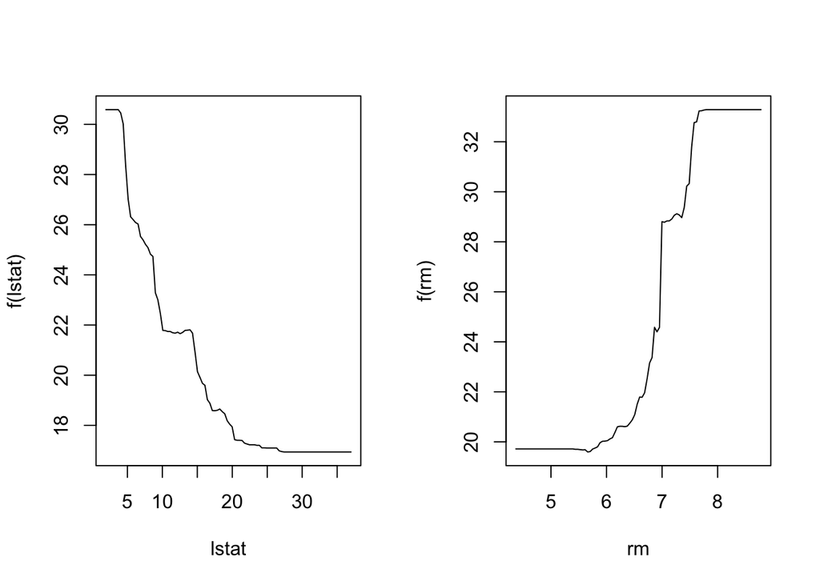

```r
par(mfrow=c(1,2))
plot(boost.boston, i="lstat")
plot(boost.boston, i="rm")
```

Lets make a prediction of the test set. with boosting, the number of trees is a tuning parameter. we need to use validaton to select the number of trees.

```r
n.trees <- seq(from=100, to=10000, by=100)
predmat <- predict(boost.boston, newdata=Boston[test,], n.trees=n.trees)
print(dim(predmat))
```

```
## [1] 206 100
```

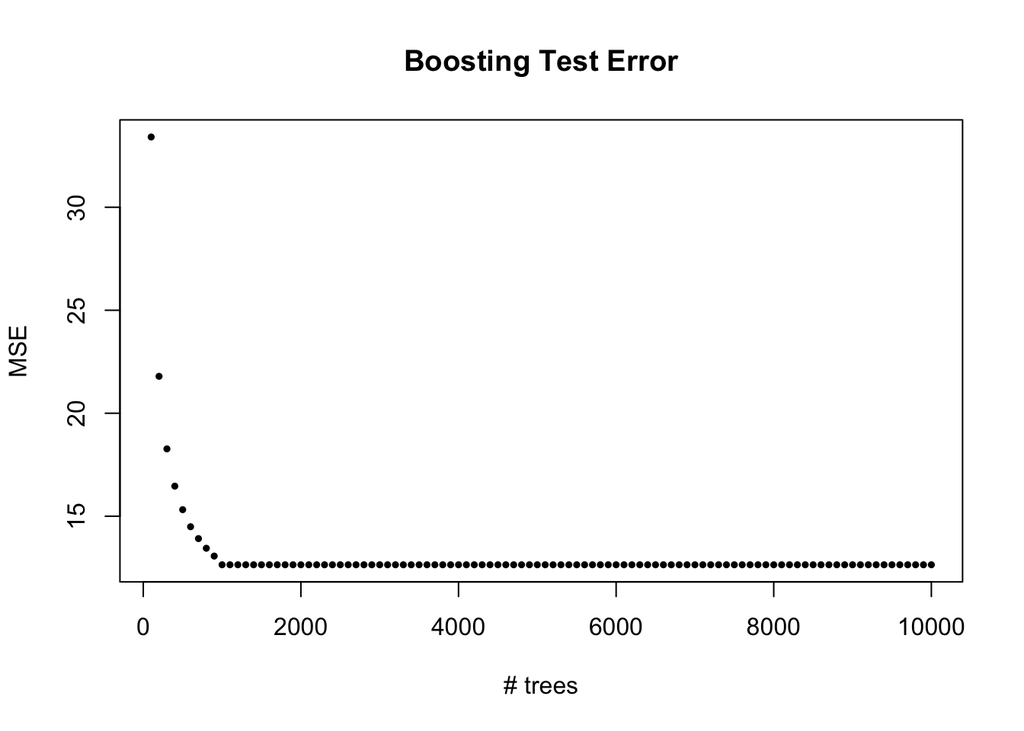

```r
berr <- apply( (predmat - Boston[test,]$medv)^2, MARGIN=2, FUN=mean )
plot(n.trees, berr, pch=19, cex=0.5, ylab="MSE", xlab="# trees", main="Boosting Test Error")
```

Boosting if tweeked often outpeforms of random forests.

For boosting you have genuine tuning params: the number of trees, the shrinkage param, and the depth

Both are very powerful methods